# Introduction to Data Science

# 1 What is Data Science?

> Data Science is the extraction of knowledge from large volumes of data that are structured or unstructured, which is a continuation of the field data mining and predictive analytics…Wikipedia

Data Science is the science of learning from data. It is a multidisciplinary field at the intersection of Domain Knowledge, Statistics and Computer Programming (although we’re going to be frightfully hip and talk about “coding”). It’s still very new and the precise scope of the role is not well defined. But, according to the Harvard Business Review, Data Science is going to be the [sexiest job of the 21st century](https://hbr.org/2012/10/data-scientist-the-sexiest-job-of-the-21st-century/).

[figure not shown]

Data Science is new and sexy. I like the idea of becoming a Zumba Instructor, but a general lack of coordination is working against me.

Data Science is the flavour of the moment, but based on recent data it’s also a particularly good career choice, giving an excellent balance between job satisfaction and general happiness.

[figure not shown]

Data Scientists rates top for work/life balance.

Data Scientists are in *massive* demand. If you have the right skills and experience you will have recruiters beating down your door daily.

> …by 2018, the United States will face a shortage of up to 190 000 data scientists with advanced training in statistics and machine learning… Game changers: Five opportunities for US growth and renewal, McKinsey Global Institute, 2013

## 1.1 Data Scientist Profile

> Data Scientist (n.): Person who is better at statistics than any software engineer and better at software engineering than any statistician.Josh Wills ( [@josh_wills](https://twitter.com/josh_wills))

What are the characteristics of a Data Scientist?

- Sound knowledge of statistical principles.
- Coding deity (of some variety).
- Knows about Machine Learning.
- A skeptic (distrustful of everything, data included). Cultivate doubt.
- Applies the Scientific Method.
- Inquisitive, creative and open-minded.
- Good social skills.
- A communicator.
- Broad business or domain knowledge.

> I know only that I don’t know anything.Socrates

The majority of Data Scientists have an advanced degree (Burtch Works Executive Recruiting 2016), either MSc or Phd, with Mathematics, Statistics, Engineering, Computer Science or Natural Science as the most common specialisations.

> … a high-ranking professional with the training and curiosity to make discoveries in the world of big data.Harvard Business Review

A Data Scientist generally has the opportunity to tackle a vast range of interesting, real-world problems. To do this they need to have a large (and continuously expanding) toolset. What would typically go into this toolset?

- Python or R (and Excel);
- Shell tools;
- Big Data tools (Hadoop, MapReduce etc.);
- SQL and NoSQL;
- Web scraping;
- Visualisation (ggplot2, plot.ly, Tableau, D3 etc.).

Technologies come in and out of vogue all the time. The most important skills for a Data Scientists is not any one particular technology, it’s the ability to learn new things quickly.

> On any given day a team member might author a multistage processing pipeline in Python, design a hypothesis test, perform a regression analysis over data samples with R, design and implement an algorithm for some data-intensive product or service in Hadoop, or communicate the results of an analysis to other members of the organization in a clear and concise fashion.Jeff Hammerbacher

## 1.2 What Does a Data Scientist Do?

> “Data Science” means the scientific study of the creation, validation and transformation of data to create meaning. “Data Scientist” means a professional who uses scientific methods to liberate and create meaning from raw data. [Professional Code of Conduct](http://www.datascienceassn.org/code-of-conduct.html), Data Science Association

Computers have changed a lot. The computer that handled the Apollo 11 mission to the Moon in 1969 had 64 kB of storage and 2 kB of RAM. The software was written in FORTRAN. The storage capacity and processing power of your cell phone is orders of magnitude larger. This phenomenal expansion in computing capabilities means that things that were mere fantasy a few years ago are now a reality (or very soon will be).

Data Scientists harness this computing power to extract information from data. Most data, in its raw state, is pretty useless. However, it’s the raw material that feeds the Data Science pipeline. Through meticulous organisation and careful analysis a Data Scientist will transform this raw material into knowledge and insights. These insights are behind some of the most successful businesses on the planet (for example, Facebook, Amazon and Tinder) and in the future will undoubtedly lead to amazing things (a cure for cancer?). Ideally these insights should be *actionable*.

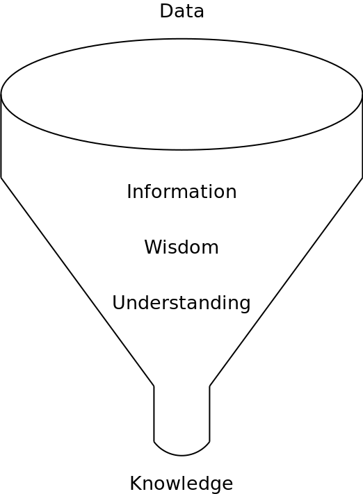

The data funnel.

A Data Scientist serves a number of objectives including:

- Asking pertinent questions;
- Defining and testing hypotheses;
- Acquiring relevant data;
- Model data and identify relationships;
- Extracting novel information and insights from data;
- Improving products;
- Constructing and communicating “data stories”;
- Supporting and improving business decisions.

Most importantly, Data Scientists are always striving to create something new.

### 1.2.1 Improving Products

Data Science is a component in a [virtuous cycle](https://en.wikipedia.org/wiki/Virtuous_circle_and_vicious_circle): gather data on product performance and usage; analyse those data and use the results to improve the product.

Of course, every product has to start somewhere, so this virtuous cycle needs to be kickstarted with an initial (satisfactory but not necessary perfect) version, a minimal viable product (MVP). There is little or no data to help developing this initial version and, as a result, this is known as the “cold start” problem.

To make this process successful it’s important to gather appropriate product and client data. More importantly, the content of these data should be carefully considered: there’s no point in having mountains of data if it’s impossible to separate the signal from the noise.

### 1.2.2 Improving Business Decisions

The contributions of Data Science to the decision making process lie beyond the production of reports or dashboards. It can factor into a wide range of business decisions, extending from scheduling and work allocation within teams all the way up to high level strategic decisions. Some examples would include:

- Product design;
- Product selection;
- Product launches.

It’s equally important to gather appropriate data for every aspect of an organisation. Data are a first class asset. Without these data the Data Scientists will be very limited in what they can do. The infrastructure and processes need to be put in place to gather all of these data. To get this in place normally requires a commitment from the executive level. However, a commitment to a data-driven culture allows Data Science to be factored into all aspects of a business and, in principle, Data Scientists can make important contributions across an entire organisation.

Forecasting and simulation are techniques commonly used to support the decision making process. Simulation is especially important since it allows you to evaluate the potential effects of a decision without actually doing the experiment live.

# 2 Case Studies

> What we need is more people who specialize in the impossible.Theodore Roethke

There are innumerable cases of Data Science applications. Here are just a few to whet your appetite:

## 2.1 Drunken Tweeting

A article published in MIT Technology Reviews describes a system for identifying [tweeting under the influence of alcohol](https://www.technologyreview.com/s/601051/machine-learning-algorithm-identifies-tweets-sent-under-the-influence-of-alcohol/).

## 2.2 Call Centre Optimisation

The basic problem with Call Centre Optimisation is matching a large number of callers to a finite number of operators. The volume of callers is also a dynamic quantity and can vary substantially over the course of a day.

Questions that should be answered might include:

- How to match particular callers to specific operators?
- What is the minimum number of operators required to ensure that no customer waits for more than 5 minutes?
- What is the optimum number of operators required to achieve a balance between waiting time and costs?

[DataProphet](http://dataprophet.com/) is a Cape Town company specialising in Call Centre Optimisation.

## 2.3 Quantified Life

Many aspects of our lives are now quantified. This might be regarded as a boon or a burden. Read about how Fitbit data helped [save a man’s life](http://www.engadget.com/2016/04/11/fitbit-data-led-doctors-to-shock-a-patient-s-heart/) (Rudner et al. 2016).

[HealthQ Technologies](http://www.healthq.co/) is a company based in Stellenbosch that’s doing some cool things in this area.

## 2.4 Construction

It’s been said that construction companies are accounting companies which erect buildings as a by-product. In the construction industry a large portion of costs are caused by material waste, poor planning and remedial work. Data from previous projects presents the possibility of identifying just where and why these costs are being incurred, which in turn allows them to be avoided or reduced in subsequent projects. Maybe in the future these companies will be able to deliver on time and on budget? ;)

[flux](https://flux.io/) is a company in Silicon Valley which provides cloud-based tools for architects, engineers and contractors.

# 3 Where’s the “Science” in Data Science?

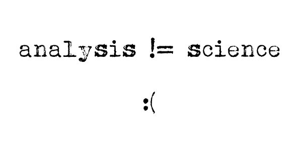

Data Analysis is not the same as Data Science.

People have got the impression that insights derived from data are more weighty than simple intuition. It’s true, the analysis of massive quantities of data has generated results that have toppled some of our most basic assumptions. So the starting point for any analysis should be an assumption that all “traditional wisdom” is wrong. At the same time, data (and the results of data analysis) can be fallible too. So this leaves us in a bit of a quandary. When do you rely on intuition and existing knowledge? And when do you abandon them and rely on fresh insights from the data?

A Data Scientist cannot afford to take anything at face value. Everything must be tested and carefully evaluated. A Data Scientist must be a Scientist and apply the *Scientific Method*. Loosely the Scientific Method consists of the following steps:

1. Find an interesting question.
2. Generate a hypothesis.
3. Make a prediction based on the hypothesis.
4. Conduct an experiment to test the prediction.
5. Analyse the results of the experiment.
6. If the results are inconclusive, return to step 2.
7. Publish the results.
8. Results subject to replication or reproduction.
9. Use results to construct a theory.

Everything starts with a question and this question needs to be as specific as possible. For example, “What does the data say about my business?” and “How can I increase my profits?” are poor questions. They are just too vague. Where does one even start? However, specific questions like “Which of my printing presses is most likely to fail next?” or “What’s the best season to launch our new clothing line?” are immediately actionable.

Don’t look too hard at the data before formulating your questions. Pose the question and then use the data to answer it. If you have delved around in the data and come up with questions, make sure that you formulate them as “Why…?” questions rather than “What…?” questions.

Generating a hypothesis is one of the most important (and often neglected stages in this process). Without this step you’ll be engaging in [data dredging](https://en.wikipedia.org/wiki/Data_dredging). A good hypothesis should be “falsifiable”, that is, it should be possible to refute that hypothesis.

- All swans are white.
- All men are mortal.

Which of these is falsifiable?

Here are some ways to ensure that what we are doing is Science:

- Have a hypothesis.
- Aim for quality over quantity.
- Be scrupulous about testing (and ensure good hygiene in your train/test partition).
- If presented with a number of otherwise equal options, go with the simplest one.

  > Simplicity is the ultimate sophistication.Leonardo da Vinci
- Think about how to communicate your results.

  > Think like a wise man but communicate in the language of the people.William Butler Yeats
- Write scripts.

  > In science consensus is irrelevant. *What is relevant is reproducible results.* The greatest scientists in history are great precisely because they broke with the consensus.Michael Crichton

# 4 Data Science Process

To be honest, the process of Data Science is less a pipeline than a cycle. Multiple iterations are generally required before you get (even close) to your final goal.

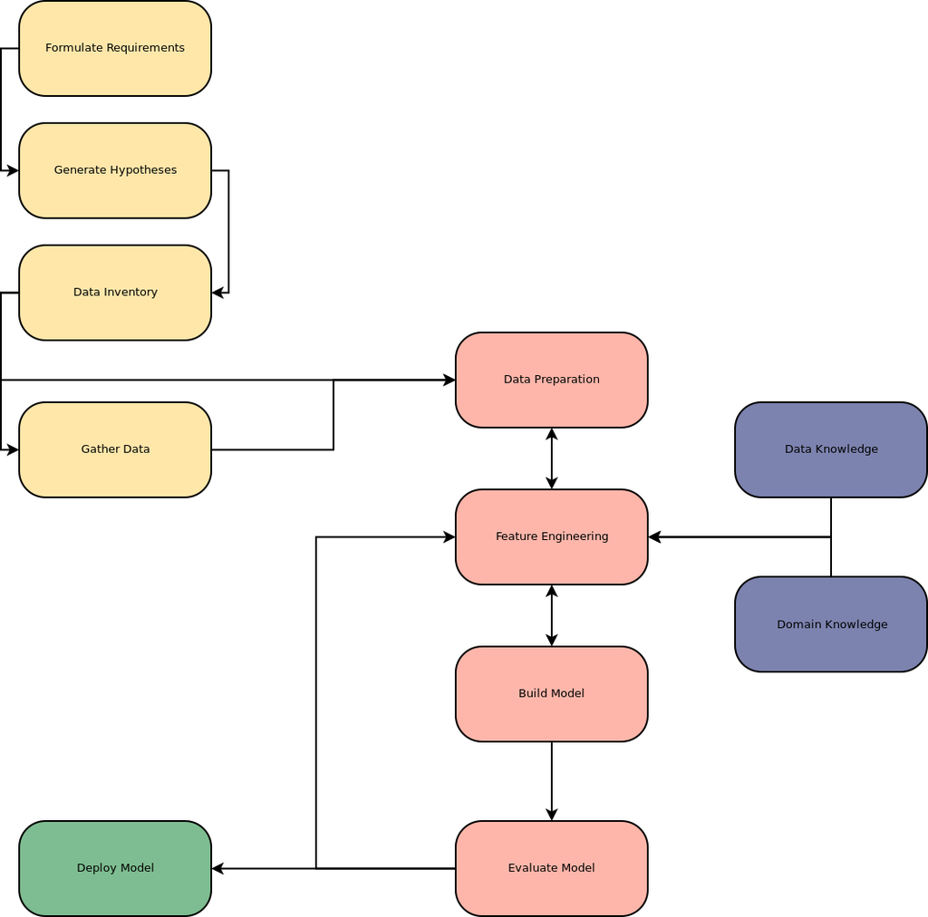

Stages in the Data Science cycle.

# 5 Movers and Shakers

There are a bunch highly influential people working in and around Data Science. It’s worth your while keeping up to date with what they are doing. Here’s a (by no means exhaustive) selection:

# 6 Data Science Competitions [Kaggle]

Wander over to [Kaggle](https://www.kaggle.com/) and check it out. We’re going to be engaging in a Kaggle competition during this course. It’ll be fun and educational. And you’ll get a rush out of defeating your peers.

# 7 Exercises

1. Read Chapters 1, 2 and 3 of “The Art of Data Science” (Peng and Matsui [2015](http://ixdatascience.bitbucket.org/01-N-introduction-data-science.html#ref-peng-art-of-data-science)).
2. Suppose that a successful technology company publishes full page advertisements weekly in major newspapers across 40 cities. Design an experiment to determine whether or not these expensive advertisements are effective in achieving their business goals.

# 8 Resources

There’s a continuous flow of new research literature relating to Data Science. Some of it is in the public domain but the rest is locked up behind paywalls. If you aren’t at an university or research institute this can be a serious bottleneck. But there are a few ways around the problem:

- email the authors directly and ask for a copy; or
- [#icanhazpdf](https://twitter.com/hashtag/icanhazpdf) [read the [details](https://en.wikipedia.org/wiki/ICanHazPDF) and don’t abuse it]; or
- [sci-hub.io](http://sci-hub.io/) (if this is blocked then you can try sci-hub.bz or sci-hub.cc).

The last two approaches are somewhat frowned upon. I won’t tell if you don’t tell. Another way to get what you are after is to search with `filetype:pdf`.

Burtch Works Executive Recruiting. 2016. “Salaries of Data Scientists.” April.

Conway, Drew, and John Myles White. 2012. *Machine Learning for Hackers*. O’Reilly.

Peng, Roger D. n.d. *R Programming for Data Science*. https://leanpub.com/rprogramming.

Peng, Roger D, and Elizabeth Matsui. 2015. *The Art of Data Science: A Guide for Anyone Who Works with Data*. https://leanpub.com/artofdatascience.

Raschka, Sebastian. 2015. *Python Machine Learning*. Packt Publishing.

Rudner, Joshua, Carol McDougall, Vivek Sailam, Monika Smith, and Alfred Sacchetti. 2016. “Interrogation of Patient Smartphone Activity Tracker to Assist Arrhythmia Management.” *Annals of Emergency Medicine*, April. doi:10.1016/j.annemergmed.2016.02.039.

White, John Myles. 2012. *Bandit Algorithms for Website Optimization*. O’Reilly.